# PEC1 Análisis de datos Ómicos

Sara Álvarez González

21 de abril de 2020

## 1. Identificar que grupos hay y a qué grupo pertenece cada muestra.

Tras haber descargado los archivos **.CEL** correspondientes al estudio elegido en la página GEO, será necesario hacerles un primer reconocimiento. Este primer paso es esencial para, a través de gráficos o resúmenes numéricos, a primera vista determinar si es preciso llevar a cabo correcciones de grandes anomalías.

Leemos los ficheros .CEL presentes en el directorio de trabajo con la función *ReadAffy*.

```r
archivos <- ReadAffy()
```

Nos interesa por tanto poder estudiar los datos fenotípicos que se encuentran indicando además el grupo al que va a pertener cada una.

En este trabajo en cuestión, vamos a encontrarnos con 40 muestras diferentes, correspondientes a muestras realizadas en ratones de tres áreas cerebrales diferentes (CA3, CA1, DG), la mitad siendo entrenadas previamente, y la mitad no. Renonmbraremos por tanto los datos fenotipicos con el nombre adecuado según la muestra se trate de una parte u otra, y hubiera sido entrenado el ratón o no.

```r
feno <- archivos@phenoData

nombres=c(rep("CA3_cont",7),rep("CA3_act",7),rep("CA1_cont",6),rep("CA1_act",6),rep("DG_cont",7),rep("DG_act",7))
nombres<-paste0(nombres,"_")
CA3_control<-paste0(nombres[1:7],1:7)
CA3_exp<-paste0(nombres[8:14],1:7)
CA1_control<-paste0(nombres[15:20],1:6)
CA1_exp<-paste0(nombres[21:26],1:6)
DG_control<-paste0(nombres[27:33],1:7)
DG_exp<-paste0(nombres[34:40],1:7)
nombres <- c(CA3_control,CA3_exp,CA1_control,CA1_exp,DG_control,DG_exp)

feno@data[,1]=nombres
feno@data
```

```
##                   sample
## GSM289058.CEL CA3_cont_1
## GSM289059.CEL CA3_cont_2
## GSM289060.CEL CA3_cont_3
## GSM289061.CEL CA3_cont_4
## GSM289062.CEL CA3_cont_5
## GSM289063.CEL CA3_cont_6
## GSM289064.CEL CA3_cont_7
## GSM289065.CEL  CA3_act_1
## GSM289066.CEL  CA3_act_2
## GSM289067.CEL  CA3_act_3
## GSM289068.CEL  CA3_act_4
## GSM289069.CEL  CA3_act_5
## GSM289070.CEL  CA3_act_6
## GSM289071.CEL  CA3_act_7
## GSM289072.CEL CA1_cont_1
## GSM289073.CEL CA1_cont_2
## GSM289074.CEL CA1_cont_3
## GSM289075.CEL CA1_cont_4
## GSM289076.CEL CA1_cont_5
## GSM289077.CEL CA1_cont_6
## GSM289078.CEL  CA1_act_1
## GSM289079.CEL  CA1_act_2
## GSM289080.CEL  CA1_act_3
## GSM289081.CEL  CA1_act_4
## GSM289082.CEL  CA1_act_5
## GSM289083.CEL  CA1_act_6
## GSM289084.CEL  DG_cont_1
## GSM289085.CEL  DG_cont_2
## GSM289086.CEL  DG_cont_3
## GSM289087.CEL  DG_cont_4
## GSM289088.CEL  DG_cont_5
## GSM289089.CEL  DG_cont_6
## GSM289090.CEL  DG_cont_7
## GSM289091.CEL   DG_act_1
## GSM289092.CEL   DG_act_2
## GSM289093.CEL   DG_act_3
## GSM289094.CEL   DG_act_4
## GSM289095.CEL   DG_act_5
## GSM289096.CEL   DG_act_6
## GSM289097.CEL   DG_act_7
```

```r
feno$sample
```

```
##  [1] "CA3_cont_1" "CA3_cont_2" "CA3_cont_3" "CA3_cont_4" "CA3_cont_5"
##  [6] "CA3_cont_6" "CA3_cont_7" "CA3_act_1"  "CA3_act_2"  "CA3_act_3"
## [11] "CA3_act_4"  "CA3_act_5"  "CA3_act_6"  "CA3_act_7"  "CA1_cont_1"
## [16] "CA1_cont_2" "CA1_cont_3" "CA1_cont_4" "CA1_cont_5" "CA1_cont_6"
## [21] "CA1_act_1"  "CA1_act_2"  "CA1_act_3"  "CA1_act_4"  "CA1_act_5"
## [26] "CA1_act_6"  "DG_cont_1"  "DG_cont_2"  "DG_cont_3"  "DG_cont_4"
## [31] "DG_cont_5"  "DG_cont_6"  "DG_cont_7"  "DG_act_1"   "DG_act_2"
## [36] "DG_act_3"   "DG_act_4"   "DG_act_5"   "DG_act_6"   "DG_act_7"
```

De esta forma forma obtendremos tantos los datos de expresión como los fenotípicos de la muestra. También podemos hacer este mismo procedimiento, pero gracias a la importación de los datos a través del archivo .txt (y no del .CEL) que nos aporta el problema.

```r
fenotipo<-file.path("matrix.txt")
fenotipo <- as.matrix(read.table(file = fenotipo, header = T, sep = "\t", row.names = 1, as.is = T))
dim(fenotipo)
```

```
## [1] 15923    40
```

```r
#las filas serán los genes y sus expresiones
print(rownames(fenotipo), max = 5)
```

```
## [1] "1367452_at" "1367453_at" "1367454_at" "1367455_at" "1367456_at"
##  [ reached getOption("max.print") -- omitted 15918 entries ]
```

```r
#las columnas serán los anteriores nombres de los archivos, que de hecho podemos cambiar como hicimos en la otra manera de hacerlo anterior
colnames(fenotipo)
```

```
##  [1] "GSM289058" "GSM289059" "GSM289060" "GSM289061" "GSM289062" "GSM289063"
##  [7] "GSM289064" "GSM289065" "GSM289066" "GSM289067" "GSM289068" "GSM289069"
## [13] "GSM289070" "GSM289071" "GSM289072" "GSM289073" "GSM289074" "GSM289075"
## [19] "GSM289076" "GSM289077" "GSM289078" "GSM289079" "GSM289080" "GSM289081"
## [25] "GSM289082" "GSM289083" "GSM289084" "GSM289085" "GSM289086" "GSM289087"
## [31] "GSM289088" "GSM289089" "GSM289090" "GSM289091" "GSM289092" "GSM289093"
## [37] "GSM289094" "GSM289095" "GSM289096" "GSM289097"
```

```r
colnames(fenotipo)=nombres
colnames(fenotipo)
```

```
##  [1] "CA3_cont_1" "CA3_cont_2" "CA3_cont_3" "CA3_cont_4" "CA3_cont_5"
##  [6] "CA3_cont_6" "CA3_cont_7" "CA3_act_1"  "CA3_act_2"  "CA3_act_3"
## [11] "CA3_act_4"  "CA3_act_5"  "CA3_act_6"  "CA3_act_7"  "CA1_cont_1"
## [16] "CA1_cont_2" "CA1_cont_3" "CA1_cont_4" "CA1_cont_5" "CA1_cont_6"
## [21] "CA1_act_1"  "CA1_act_2"  "CA1_act_3"  "CA1_act_4"  "CA1_act_5"
## [26] "CA1_act_6"  "DG_cont_1"  "DG_cont_2"  "DG_cont_3"  "DG_cont_4"
## [31] "DG_cont_5"  "DG_cont_6"  "DG_cont_7"  "DG_act_1"   "DG_act_2"
## [36] "DG_act_3"   "DG_act_4"   "DG_act_5"   "DG_act_6"   "DG_act_7"
```

## 2. Control de calidad de los datos crudos.

En primer lugar se ha hecho una análisis del control de calidad de los datos a través de datos gráficos, más intuitivamente analizables como facilitador de un screening sobre los datos crudos:

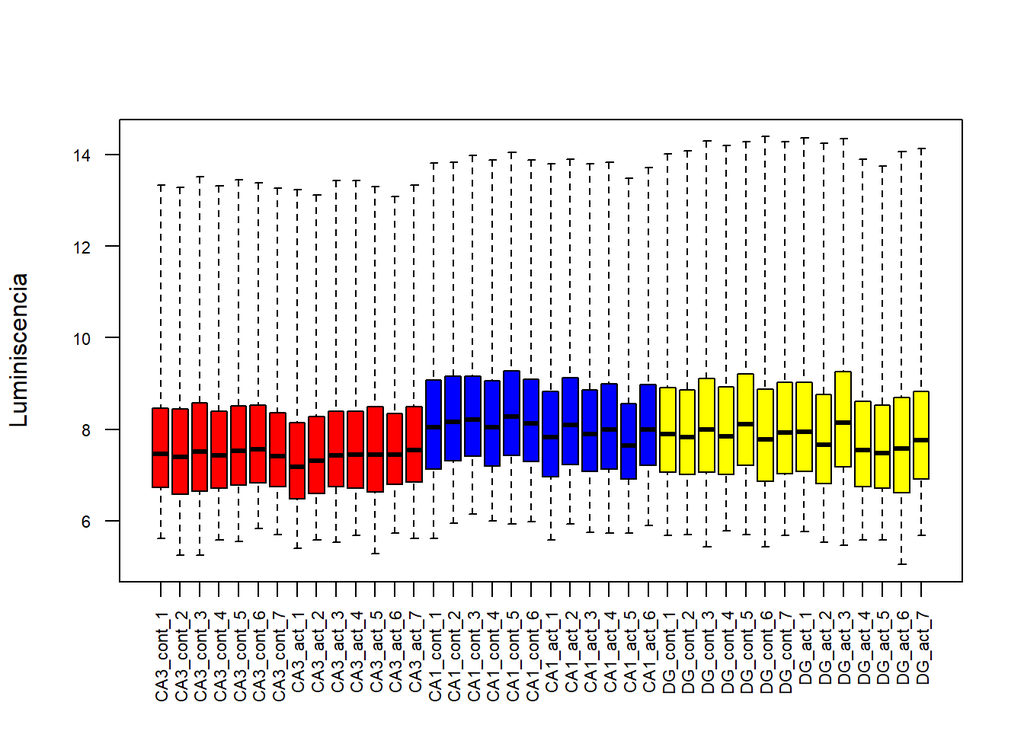

```r
#boxplot
colores = c(rep("red",14),rep("blue",12),rep("yellow",14))
boxplot(archivos,las=2, cex.axis=0.7, names=nombres, col=colores,ylab="Luminiscencia")
```

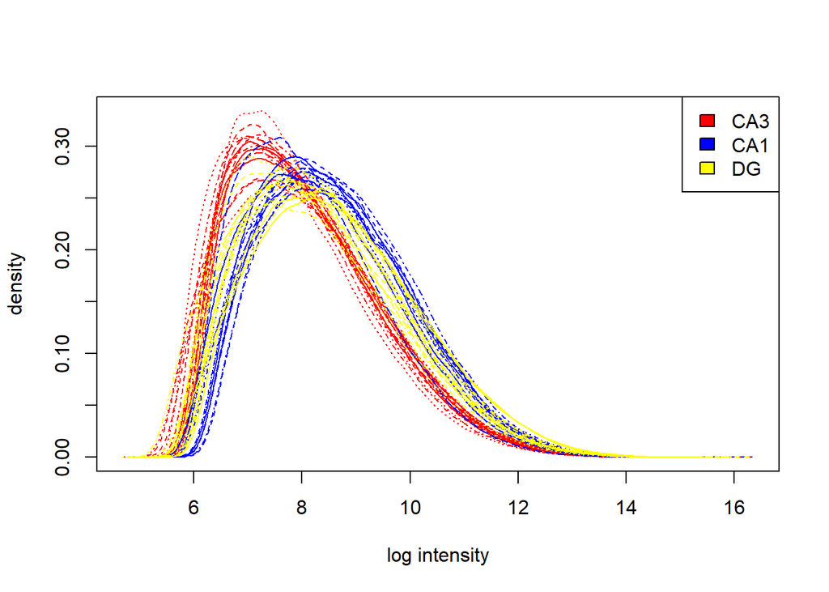

```r
#histograma
hist(archivos,col=colores)
legend("topright", c("CA3", "CA1", "DG"), fill=c("red","blue","yellow"))
```

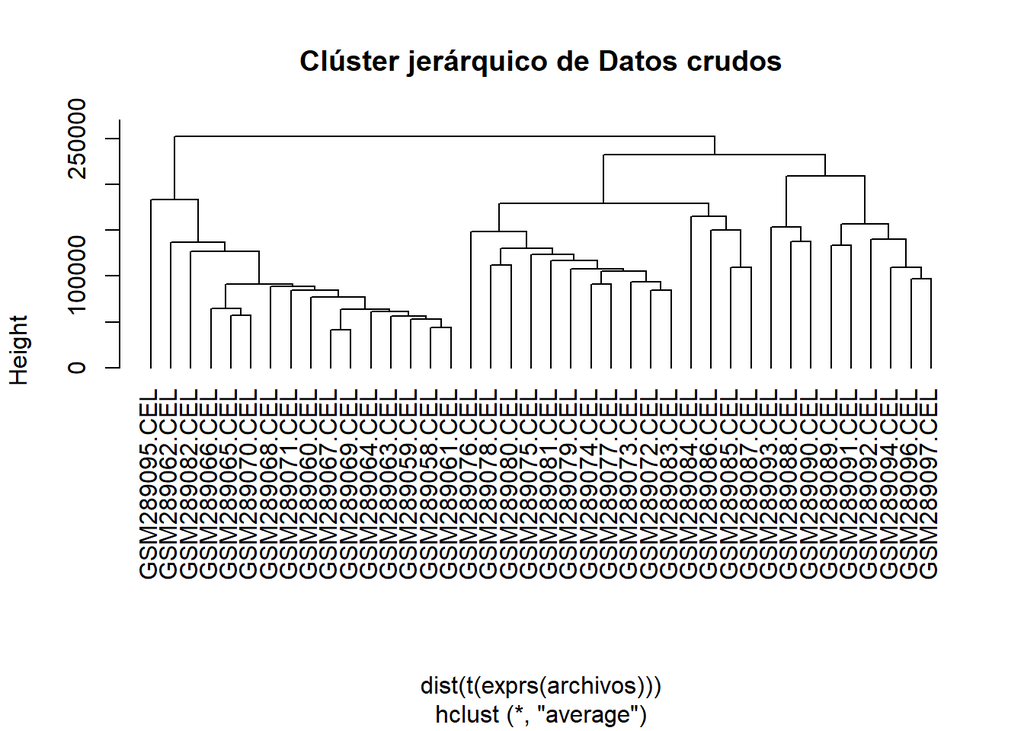

```r
#clúster jerárquico
clust.euclid.average <- hclust(dist(t(exprs(archivos))),method="average")
plot(clust.euclid.average, main="Clúster jerárquico de Datos crudos",  hang=-1)
```

Los dos primeros (boxplot e histograma) son los dos gráficos que mejor nos permiten obsevar las disparidades de estos datos en crudo (*raw data*). Esto es así debido a que el primero de ellos nos permite ver la distribución de las luminiscencias, mientras que el segundo ver la similitud en forma y posición de las diferentes muestras.Se ha facilitado la interpretación de estos dos primeros gráficos a través de colores, pintando los de cada región de un color, incluyendo a los de control o experimentales.

A simple vista, el boxplot nos muestra cierta variabilidad entre los datos, aunque vemos que los que son de la misma región van a moverse por una zona similar de luminiscencia, aunque no es posible decir si esta relación es significativa a simple vista. En cuanto al histograma, podemos observar que de nuevo, aparentemente, se mueven por las mismas zonas aquellas observaciones realizadas a las zonas homónimas.

El tercer gráfico elegido para realizar una pequeña visual, será el de la jerarquización de las muestras a través de clústers. De manera aparente, da la sensación de que sí que existe cierta distinción entre las tres zonas analizadas, aunque tal y como son los datos resulta difícil sacar una conclusión.

Será por tanto necesario, previo a sacar ninguna conclusión o analizarlos, llevar a cabo una normalización de los mismos.

Sin embargo, antes de pasar a la normalización, también resulta interesante echar un ojo al resultado del control de calidad que la función *qc* nos reporta:

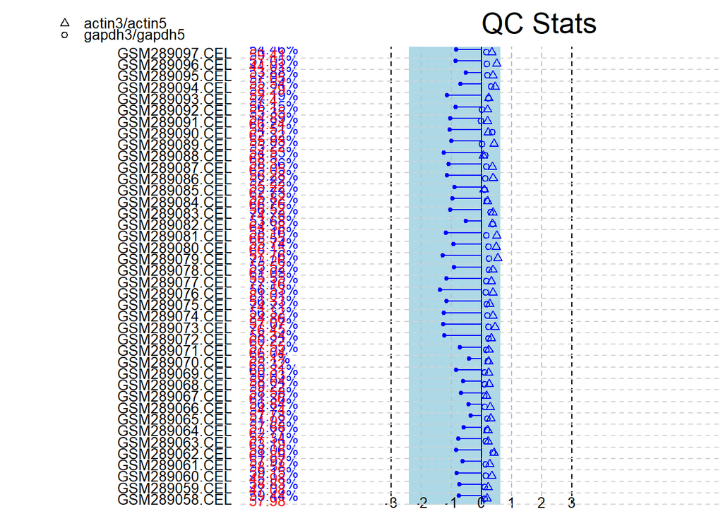

```r
calidad <- qc(archivos)
plot(calidad)
```

Este informe nos enseña, desde un gráfico parcialmente descriptivo: el nombre del fichero .CEL, el porcentaje de sondas que han detectado fluorescencia (con la fluorescencia de fondo) y en la tercera columna, siendo la más destacable en nuestro caso, nos va a decir, en un primer momento, la calidad relativa a problemas de degradación del RNA. Debido a que en nuestro caso, todas van a ser azules, esto indicaría que no es algo por lo que deberíamos descartar ninguna de las muestras.

De manera extra, y aunque tampoco resulta demasiado funcional teniendo en cuenta la cantidad de datos con los que estamos trabajando, también sería posible hacer un análisis de calidad representando una imagen global de la fluorescencia de los microarrays con la función *image* con la columna que seleccionemos (fichero .CEL, es decir, la muestra entera).

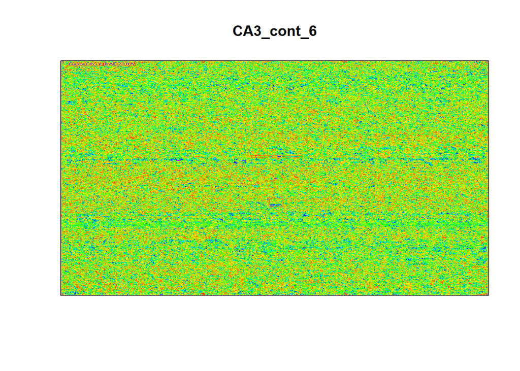

```r
image(archivos[,6],col=rainbow(100),main="CA3_cont_6")
```

## 3. Normalización

Para llevar a cabo esta tarea, se ha elegido el método de **RMA**, debido que se trata de una muestra de microarray de un color, concretamente Affymetrix. Este método de resumen y normalización va a aportar mejores antes las deficiencias de los anteriores métodos (MAS4 y MAS5). Los pasos que va a llevar a cabo este **Robust multi-array average** serán: un ajuste del ruido de fondo, la toma de logaritmos de base 2 ajustados por el anterior, la normalización por cuantiles de los valores anteriores y estimación de las intensidades para, en este caso, cada gen para cada área en su correspondiente estado (control o experimental).

```r
normalizacion <- rma(archivos)
```

```
## Background correcting
## Normalizing
## Calculating Expression
```

```r
normalizacion
```

```
## ExpressionSet (storageMode: lockedEnvironment)
## assayData: 15923 features, 40 samples
##   element names: exprs
## protocolData
##   sampleNames: GSM289058.CEL GSM289059.CEL ... GSM289097.CEL (40 total)
##   varLabels: ScanDate
##   varMetadata: labelDescription
## phenoData
##   sampleNames: GSM289058.CEL GSM289059.CEL ... GSM289097.CEL (40 total)
##   varLabels: sample
##   varMetadata: labelDescription
## featureData: none
## experimentData: use 'experimentData(object)'
## Annotation: rae230a
```

```r
class(normalizacion)
```

```
## [1] "ExpressionSet"
## attr(,"package")
## [1] "Biobase"
```

```r
matriz <- exprs(normalizacion)
head(matriz,2)
```

```
##            GSM289058.CEL GSM289059.CEL GSM289060.CEL GSM289061.CEL
## 1367452_at      10.33847      10.26520      10.36293      10.43361
## 1367453_at      10.25297      10.12655      10.10761      10.25720
##            GSM289062.CEL GSM289063.CEL GSM289064.CEL GSM289065.CEL
## 1367452_at      10.31353      10.42054      10.44688      10.38352
## 1367453_at      10.10621      10.12238      10.12415      10.06020
##            GSM289066.CEL GSM289067.CEL GSM289068.CEL GSM289069.CEL
## 1367452_at      10.36702      10.38417      10.46406      10.36579
## 1367453_at      10.01125      10.08462      10.02598      10.11628
##            GSM289070.CEL GSM289071.CEL GSM289072.CEL GSM289073.CEL
## 1367452_at      10.24525      10.32761     10.078227     10.055450
## 1367453_at      10.07675      10.13945      9.794166      9.769356
##            GSM289074.CEL GSM289075.CEL GSM289076.CEL GSM289077.CEL
## 1367452_at     10.114843      9.983295     10.112662     10.154834
## 1367453_at      9.860003      9.653173      9.684552      9.722631
##            GSM289078.CEL GSM289079.CEL GSM289080.CEL GSM289081.CEL
## 1367452_at      10.06355      10.14889     10.061830      10.35077
## 1367453_at       9.80373       9.78729      9.694397       9.92109
##            GSM289082.CEL GSM289083.CEL GSM289084.CEL GSM289085.CEL
## 1367452_at     10.063185     10.239902     10.359753     10.412361
## 1367453_at      9.800906      9.768639      9.948877      9.967769
##            GSM289086.CEL GSM289087.CEL GSM289088.CEL GSM289089.CEL
## 1367452_at     10.387006      10.41335     10.168820     10.479748
## 1367453_at      9.885121      10.00606      9.928455      9.877195
##            GSM289090.CEL GSM289091.CEL GSM289092.CEL GSM289093.CEL
## 1367452_at     10.294888     10.235090     10.459529     10.096285
## 1367453_at      9.800809      9.774588      9.831591      9.751671
##            GSM289094.CEL GSM289095.CEL GSM289096.CEL GSM289097.CEL
## 1367452_at     10.254227     10.222825     10.370578     10.496946
## 1367453_at      9.931648      9.987385      9.917921      9.879505
```

Es de destacar que para llevar a cabo esta normalización, antes de convertirla en una matriz facilmente manipulable para posteriores funciones, el objeto que nos devuelve será uno del tipo *ExpressionSet*, como el trabajado en los foros. Como su propia clase lo define, es como un paso intermedio entre los datos tal y como nos los dan, a manipularlos de manera sencilla (subconjuntos de datos, copia, cambio de formato…). Obtendremos así, con una simple transformación con la función *exprs*, una matriz con los datos sumarizados y normalizados.

```r
dim(matriz)
```

```
## [1] 15923    40
```

Es decir, obtenemos una matriz con la expresión del ARN como filas, mientras que como columnas estarán los 40 experimentos con las distintas condiciones comentadas previamente. De hecho, por comodidad podemos cambiárselo para que sea más sencillo, como anteriormente.

```r
colnames(matriz) <- nombres
head(matriz,2)
```

```
##            CA3_cont_1 CA3_cont_2 CA3_cont_3 CA3_cont_4 CA3_cont_5 CA3_cont_6
## 1367452_at   10.33847   10.26520   10.36293   10.43361   10.31353   10.42054
## 1367453_at   10.25297   10.12655   10.10761   10.25720   10.10621   10.12238
##            CA3_cont_7 CA3_act_1 CA3_act_2 CA3_act_3 CA3_act_4 CA3_act_5
## 1367452_at   10.44688  10.38352  10.36702  10.38417  10.46406  10.36579
## 1367453_at   10.12415  10.06020  10.01125  10.08462  10.02598  10.11628
##            CA3_act_6 CA3_act_7 CA1_cont_1 CA1_cont_2 CA1_cont_3 CA1_cont_4
## 1367452_at  10.24525  10.32761  10.078227  10.055450  10.114843   9.983295
## 1367453_at  10.07675  10.13945   9.794166   9.769356   9.860003   9.653173
##            CA1_cont_5 CA1_cont_6 CA1_act_1 CA1_act_2 CA1_act_3 CA1_act_4
## 1367452_at  10.112662  10.154834  10.06355  10.14889 10.061830  10.35077
## 1367453_at   9.684552   9.722631   9.80373   9.78729  9.694397   9.92109
##            CA1_act_5 CA1_act_6 DG_cont_1 DG_cont_2 DG_cont_3 DG_cont_4
## 1367452_at 10.063185 10.239902 10.359753 10.412361 10.387006  10.41335
## 1367453_at  9.800906  9.768639  9.948877  9.967769  9.885121  10.00606
##            DG_cont_5 DG_cont_6 DG_cont_7  DG_act_1  DG_act_2  DG_act_3
## 1367452_at 10.168820 10.479748 10.294888 10.235090 10.459529 10.096285
## 1367453_at  9.928455  9.877195  9.800809  9.774588  9.831591  9.751671
##             DG_act_4  DG_act_5  DG_act_6  DG_act_7
## 1367452_at 10.254227 10.222825 10.370578 10.496946
## 1367453_at  9.931648  9.987385  9.917921  9.879505
```

## 4. Control de calidad de los datos normalizados

De la misma manera que hicimos previamente, la representación gráfica será la mejor manera de llevar a cabo un control de calidad de los datos, en este caso normalizados. Como los datos siguen siendo los mismos, utilizaremos de nuevo los dos métodos gráficos que más sentido tenían en nuestro trabajo. Como complemento, es interesante si ponemos al lado la gráfica correspondiente a cuando estaban sin normalizar, percibiendo mejor el cambio de un caso a otro:

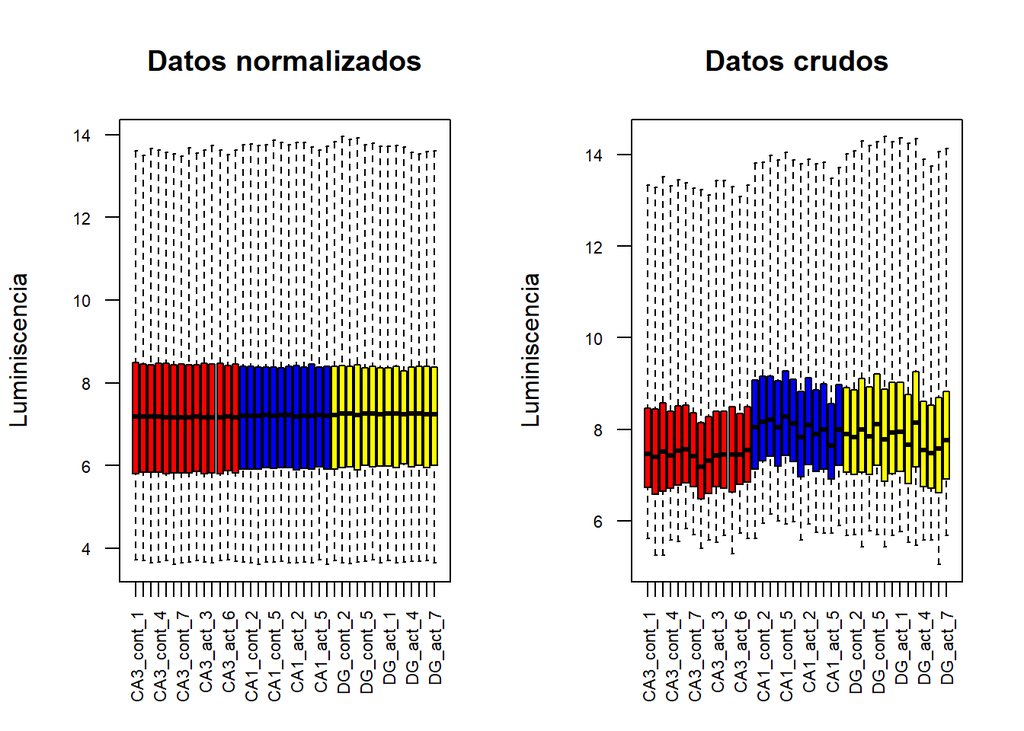

```r
#boxplot
par(mfrow=c(1,2))
boxplot(normalizacion,las=2, cex.axis=0.7,names=nombres, col=colores,ylab="Luminiscencia",main="Datos normalizados")
boxplot(archivos,las=2, cex.axis=0.7, names=nombres, col=colores,ylab="Luminiscencia",main="Datos crudos")
```

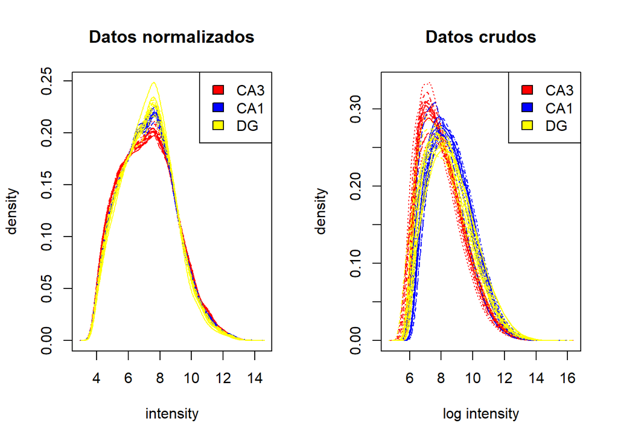

```r
#histograma
par(mfrow=c(1,2))
hist(normalizacion,col=colores,main="Datos normalizados")
legend("topright", c("CA3", "CA1", "DG"), fill=c("red","blue","yellow"))
hist(archivos,col=colores,main="Datos crudos")
legend("topright", c("CA3", "CA1", "DG"), fill=c("red","blue","yellow"))
```

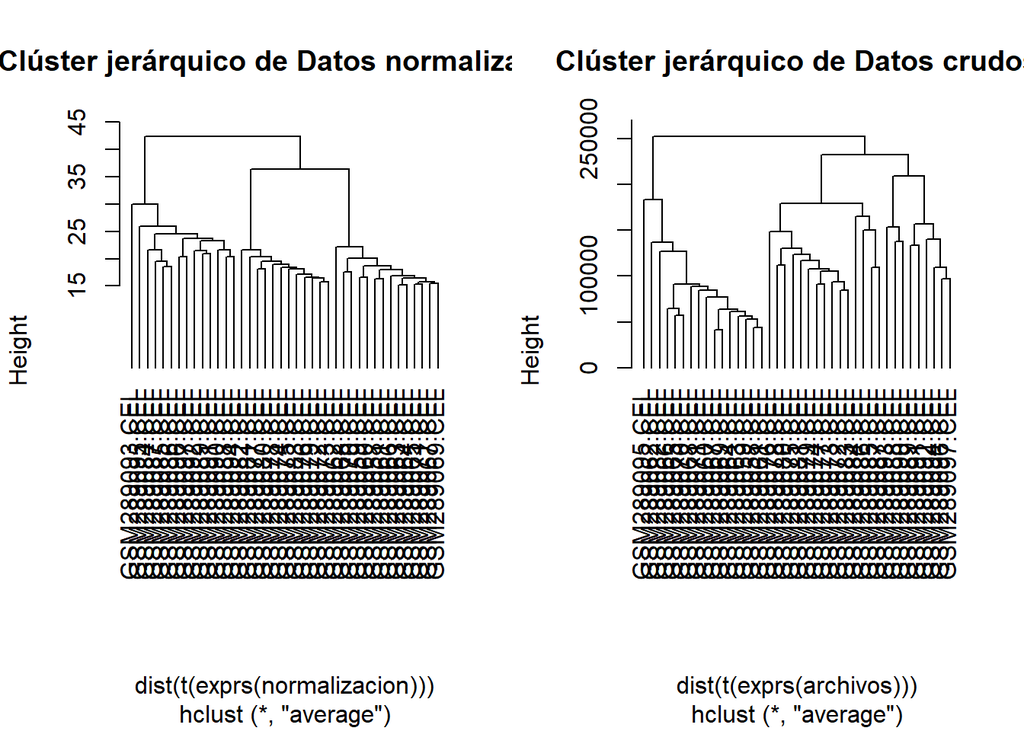

```r
#cluster
par(mfrow=c(1,2))
clust.euclid.average <- hclust(dist(t(exprs(normalizacion))),method="average")
plot(clust.euclid.average, main="Clúster jerárquico de Datos normalizados",  hang=-1)
clust.euclid.average <- hclust(dist(t(exprs(archivos))),method="average")
plot(clust.euclid.average, main="Clúster jerárquico de Datos crudos",  hang=-1)
```

Como podemos ver, ahora sí hemos logrado tener unos datos que se muevan todos en los mismos valores, pudiendo analizarlos de manera más segura y habiendo quitado parte del sesgo que pudieran traer por la disparidad previa de unos con otros. En los tres gráficos que aquí se muestran, se puede comprobar que ahora, al moverse adecuadamente las expresiones de los genes dentro de un mismo rango, llevar a cabo los siguientes análisis será más adecuado. Pormenorizadamente, los boxplot lograron establecerse en un mismo grado de luminiscencia, el histograma logarítmico homogeneizarse en las tres áreas cerebrales estudiadas y el clústering jerárquico ser capaz de subdividir los datos en las tres secciones diferenciadas de manera más clara y acertada frente a los datos en crudo.

## 6. + 7. Identificación de genes diferencialmente expresados y anotación de los resultados

Aquí vemos cómo los datos se distribuyen claramente diferenciados según las áreas del cerebro de las que fueron extraídas, aunque el hecho de si eran Control o Experimental no está tan claro.

En primer lugar, ya que no viene hecho por defecto, será necesario añadir los datos fenotípicos correspondientes a los datos del problema para así poder factorizar en niveles la muestra de datos:

```r
feno@data[,2] <- c(rep("CA3",14),rep("CA1",12),rep("DG",14))
feno@data[,3] <- c(rep("Control",7),rep("Activado",7),rep("Control",6),rep("Activado",6),rep("Control",7),rep("Activado",7))
colnames(feno@data)[2] <- "area"
colnames(feno@data)[3] <- "estado"
head(feno@data,2)
```

```
##                   sample area  estado
## GSM289058.CEL CA3_cont_1  CA3 Control
## GSM289059.CEL CA3_cont_2  CA3 Control
```

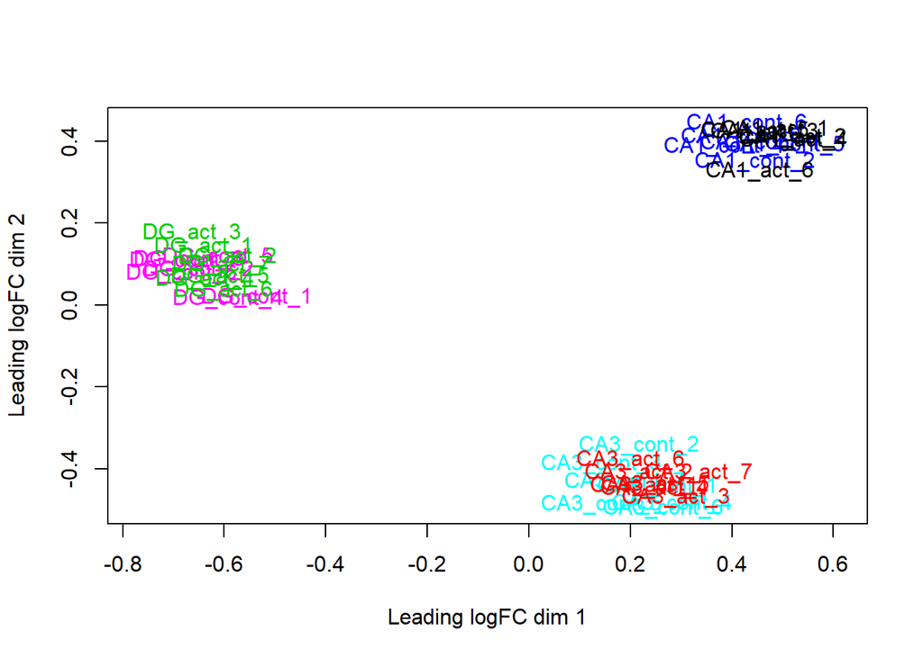

```r
area <- factor(feno$area)
estado <- factor(feno$estado)

grupo <- interaction(area,estado)
plotMDS(matriz,col=as.numeric(grupo))
```

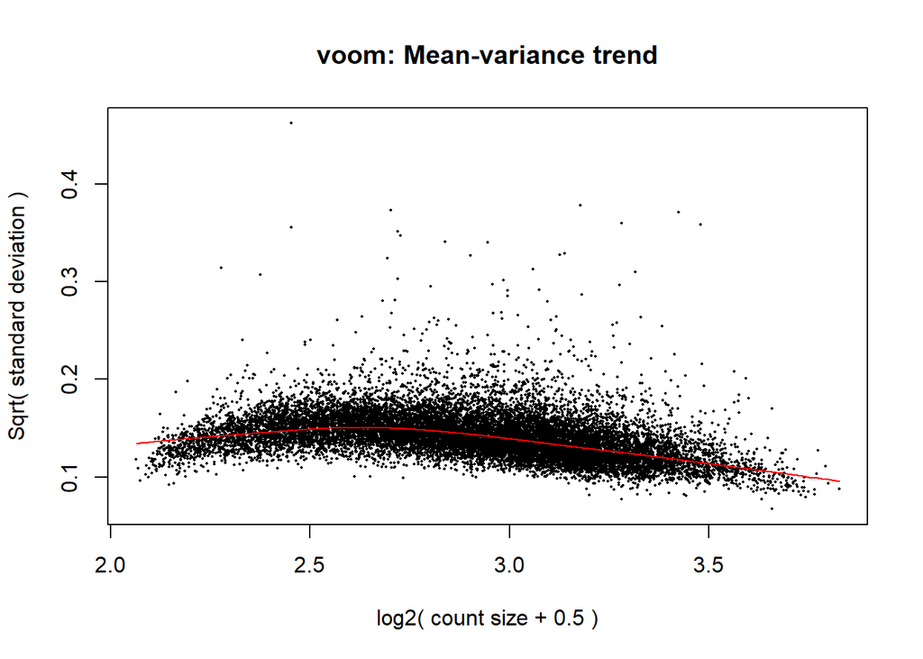

```r
modelo <- model.matrix(~0+grupo)
ajuste <- voom(matriz,modelo,plot=T)
```

La función *voom* nos permite ver a través de un gráfico la estimación de la relación entre la media y la varianza del log-counts, aportando un peso para cada observación.

Ahora procedemos a utilizar el modelo linear a través de mínimos cuadrados con la función de *lmFit*:

```r
ajuste2 <- lmFit(ajuste,modelo)
head(coef(ajuste2))
```

```
##            grupoCA1.Activado grupoCA3.Activado grupoDG.Activado
## 1367452_at          6.531304          6.562325         6.550058
## 1367453_at          6.481954          6.523441         6.490512
## 1367454_at          6.366625          6.391269         6.383804
## 1367455_at          6.493399          6.545348         6.485526
## 1367456_at          6.492595          6.481077         6.459097
## 1367457_at          6.493182          6.523259         6.459148
##            grupoCA1.Control grupoCA3.Control grupoDG.Control
## 1367452_at         6.523217         6.562441        6.557617
## 1367453_at         6.476670         6.534031        6.497532
## 1367454_at         6.365239         6.390954        6.379991
## 1367455_at         6.484341         6.547953        6.497466
## 1367456_at         6.481890         6.455867        6.457121
## 1367457_at         6.495809         6.525774        6.488813
```

Y ahora ya podemos hacer comparaciones entre grupos, a través de los contraster de la función *makeContrast*.

Haremos tres comparaciones en primer lugar, para ver si existe diferencia entre la expresión de genes en cada área con sus respectivos controles a sujetos experimentales:

1. Comparación áreas **CA3 Control vs Activadas**:

```r
contraste_CA3 <- makeContrasts(grupoCA3.Control - grupoCA3.Activado, levels = colnames(coef(ajuste2)))
contraste_CA3
```

```
##                    Contrasts
## Levels              grupoCA3.Control - grupoCA3.Activado
##   grupoCA1.Activado                                    0
##   grupoCA3.Activado                                   -1
##   grupoDG.Activado                                     0
##   grupoCA1.Control                                     0
##   grupoCA3.Control                                     1
##   grupoDG.Control                                      0
```

```r
gen_CA3 <- contrasts.fit(ajuste2,contraste_CA3)
gen_CA3 <- eBayes(gen_CA3)
table_CA3 <- topTable(gen_CA3,sort.by = "P",n=Inf)
head(table_CA3,5)
```

```
##                  logFC  AveExpr         t      P.Value    adj.P.Val         B
## 1371103_at -0.07502642 6.436793 -8.310044 1.582528e-10 2.519859e-06 13.812584
## 1399152_at -0.10838799 6.251388 -7.335068 3.945788e-09 3.141439e-05 10.675028
## 1387385_at -0.08346737 6.254654 -6.960353 1.382870e-08 5.934661e-05  9.459394
## 1390645_at -0.07298211 6.408376 -6.803652 2.340988e-08 5.934661e-05  8.859663
## 1369541_at -0.10992912 6.035072 -6.791900 2.435352e-08 5.934661e-05  8.985571
```

```r
length(which(table_CA3$adj.P.Val < 0.05))
```

```
## [1] 317
```

```r
table_CA3$Genes <- rownames(table_CA3)
table_CA3 <- table_CA3[,c("Genes",names(table_CA3)[1:6])]
write.table(table_CA3,file="CA3_Control_vs_Activado.txt",row.names = F,sep = "\t",quote = F)
```

En esta comparación encontraremos **317** genes diferencialmente expresados (DE) con una significación de **umbral 0.05**. Además, los resultados de estos genes se guardarán en un *.txt*.

2. Comparación áreas **CA1 Control vs Activadas**:

```r
contraste_CA1 <- makeContrasts(grupoCA1.Control - grupoCA1.Activado, levels = colnames(coef(ajuste2)))
contraste_CA1
```

```
##                    Contrasts
## Levels              grupoCA1.Control - grupoCA1.Activado
##   grupoCA1.Activado                                   -1
##   grupoCA3.Activado                                    0
##   grupoDG.Activado                                     0
##   grupoCA1.Control                                     1
##   grupoCA3.Control                                     0
##   grupoDG.Control                                      0
```

```r
gen_CA1 <- contrasts.fit(ajuste2,contraste_CA1)
gen_CA1 <- eBayes(gen_CA1)
table_CA1 <- topTable(gen_CA1,sort.by = "P",n=Inf)
head(table_CA1,5)
```

```
##                  logFC  AveExpr         t      P.Value adj.P.Val        B
## 1373615_at -0.08812681 6.121161 -4.816925 1.798389e-05 0.1036099 2.557110
## 1372953_at  0.06148117 6.642369  4.796265 1.923722e-05 0.1036099 2.244935
## 1375961_at -0.11226255 6.105005 -4.791775 1.952079e-05 0.1036099 2.477321
## 1368865_at  0.08599167 6.272638  4.594516 3.699999e-05 0.1258038 1.824603
## 1369694_at  0.09256918 5.819798  4.574192 3.950379e-05 0.1258038 1.896897
```

```r
length(which(table_CA1$adj.P.Val < 0.05))
```

```
## [1] 0
```

```r
table_CA1$Genes <- rownames(table_CA1)
table_CA1 <- table_CA1[,c("Genes",names(table_CA1)[1:6])]
write.table(table_CA1,file="CA1_Control_vs_Activado.txt",row.names = F,sep = "\t",quote = F)
```

En este caso, a pesar de encontrarse el umbral ya a **0.05**, siendo lo máximo a lo que se debería admitir para que sea efectivamente significativa esta sobreexpresión de genes DE, el resultado nos da **0**. Debido a ello, este área podemos decir que no va a encontrar diferencias significativas en cuanto a expresión habiéndose activado con el experimento llevado a cabo, frente a las muestras control, no teniéndola en cuenta para la búsqueda de significación biológica. Aún así, los resultados de estos genes también se guardarán en un *.txt*.

3. Comparación áreas **DG Control vs Activadas**:

```r
contraste_DG <- makeContrasts(grupoDG.Control - grupoDG.Activado, levels = colnames(coef(ajuste2)))
contraste_DG
```

```
##                    Contrasts
## Levels              grupoDG.Control - grupoDG.Activado
##   grupoCA1.Activado                                  0
##   grupoCA3.Activado                                  0
##   grupoDG.Activado                                  -1
##   grupoCA1.Control                                   0
##   grupoCA3.Control                                   0
##   grupoDG.Control                                    1
```

```r
gen_DG <- contrasts.fit(ajuste2,contraste_DG)
gen_DG <- eBayes(gen_DG)
table_DG <- topTable(gen_DG,sort.by = "P",n=Inf)
head(table_DG,5)
```

```
##                  logFC  AveExpr         t      P.Value    adj.P.Val         B
## 1370274_at  0.03740920 6.839526  7.825818 7.740648e-10 1.232543e-05 11.964304
## 1392474_at -0.05541218 6.333560 -6.590137 4.802508e-08 2.409042e-04  8.206075
## 1373800_at -0.05852621 5.718851 -6.575879 5.038782e-08 2.409042e-04  8.322310
## 1371639_at  0.05292044 6.530368  6.521504 6.051730e-08 2.409042e-04  7.870540
## 1398883_at  0.08088987 6.376027  6.367591 1.016602e-07 2.886014e-04  7.446037
```

```r
length(which(table_DG$adj.P.Val < 0.05))
```

```
## [1] 1052
```

```r
table_DG$Genes <- rownames(table_DG)
table_DG <- table_DG[,c("Genes",names(table_DG)[1:6])]
write.table(table_DG,file="DG_Control_vs_Activado.txt",row.names = F,sep = "\t",quote = F)
```

En esta comparación encontraremos **1052** genes DE con una significación de **umbral 0.05**. Además, los resultados de estos genes se guardarán en un *.txt*.

## 8. Comparación entre distintas comparaciones (si hay más de una comparación, ver que genes han sido seleccionados en más de una comparación)

En este apartado, seleccionaremos aquellos genes DE que han destacado como tal en las dos áreas cerebrales que aquí estamos analizando (debido al descarte de CA1 por lo que se explicó en el apartado anterior).

```r
length(which(table_CA3$adj.P.Val < 0.05 & table_DG$adj.P.Val < 0.05))
```

```
## [1] 317
```

La comparación muestra por tanto:

- Genes DE en CA3 vs DG: **317**, existiendo por tanto cierta cantidad de genes DE no coincidentes.

## 9. Análisis de significación biológica (“Gene Enrichment Analysis”)

Para realizar este análisis, se utilizará el test de enrichment de términos GO, junto con los datos de los genes DE, empleando el estadísitico del **test de Fisher**.

Primero deberemos de crear un objeto tipo **topGOdata** que contenga todos los ID de los genes DE y sus puntuaciones, las anotaciones GO, la estructura jerárquica GO y toda la otra información necesaria para llevar a cabo el análisis de enriquecimiento.

Debemos por tanto crear las demás variables para unirlas todas en el nuevo objeto. Primero será necesario obtener los símbolos de los genes y los GO asociados con la librería *biomaRt*:

```r
#Obtenemos ID
ensembl <- useEnsembl(biomart = "ensembl")
searchDatasets(mart = ensembl, pattern = "(R|r)at")
```

```
##                      dataset
## 52       dordii_gene_ensembl
## 61   enaucrates_gene_ensembl
## 65  fdamarensis_gene_ensembl
## 75     hgfemale_gene_ensembl
## 76       hgmale_gene_ensembl
## 94     mauratus_gene_ensembl
## 117     ngalili_gene_ensembl
## 158 rnorvegicus_gene_ensembl
## 161     saurata_gene_ensembl
##                                                      description
## 52                                 Kangaroo rat genes (Dord_2.0)
## 61                           Live sharksucker genes (fEcheNa1.1)
## 65                              Damara mole rat genes (DMR_v1.0)
## 75               Naked mole-rat female genes (HetGla_female_1.0)
## 76                        Naked mole-rat male genes (HetGla_1.0)
## 94                              Golden Hamster genes (MesAur1.0)
## 117 Upper Galilee mountains blind mole rat genes (S.galili_v1.0)
## 158                                         Rat genes (Rnor_6.0)
## 161                         Gilthead seabream genes (fSpaAur1.1)
##               version
## 52           Dord_2.0
## 61         fEcheNa1.1
## 65           DMR_v1.0
## 75  HetGla_female_1.0
## 76         HetGla_1.0
## 94          MesAur1.0
## 117     S.galili_v1.0
## 158          Rnor_6.0
## 161        fSpaAur1.1
```

```r
#Consultamos cómo se llama la variable que necesitaremos buscar
ensembl <- useEnsembl(biomart = "ensembl",dataset = "rnorvegicus_gene_ensembl")
annotation(archivos)
```

```
## [1] "rae230a"
```

```r
searchFilters(mart = ensembl,pattern = "rae230a")
```

```
##                  name                                description
## 102 with_affy_rae230a              With AFFY RAE230A probe ID(s)
## 119      affy_rae230a AFFY RAE230A probe ID(s) [e.g. 1375651_at]
```

```r
searchAttributes(mart = ensembl,pattern = "GO")
```

```
##                      name             description         page
## 39                  go_id       GO term accession feature_page
## 40              name_1006            GO term name feature_page
## 41        definition_1006      GO term definition feature_page
## 42        go_linkage_type   GO term evidence code feature_page
## 43         namespace_1003               GO domain feature_page
## 44   goslim_goa_accession GOSlim GOA Accession(s) feature_page
## 45 goslim_goa_description  GOSlim GOA Description feature_page
```

```r
searchAttributes(mart = ensembl,pattern = "symbol")
```

```
##                 name                description         page
## 58        mgi_symbol                 MGI symbol feature_page
## 78        rgd_symbol                 RGD symbol feature_page
## 83 uniprot_gn_symbol UniProtKB Gene Name symbol feature_page
```

```r
biom <- useMart(biomart = "ensembl",dataset = "rnorvegicus_gene_ensembl")
```

En este caso, para el dataset **rnorvegicus_gene_ensembl** emplearemos como filter **affy_rae230a** y como atributos **rgd_symbol** y **go_id**.

Como los genes DE coincidentes en las dos áreas son los totales del área CA3 (recordemos que solo trabajamos con CA3 y DG), se cogen los ID de esta tabla en concreto, guardando solo los que fueron significativos en ese caso. Convertimos al nombre del gen correspondientes y guardamos ese vector:

```r
ID_DE <- table_CA3[table_CA3$adj.P.Val < 0.05,]
ID_DE <- rownames(ID_DE)

# transformamos a un lengaje que nos ayude a comparar posteriormente
ID_DE<-getBM(attributes =  c("rgd_symbol"), filters = "affy_rae230a", values =ID_DE, mart = biom)
```

```
## Cache found
```

```r
ID_DE <- ID_DE[,1]

length(ID_DE)
```

```
## [1] 276
```

Los genes DE se redujeron debido a que la misma nomenclatura estaba representando al mismo gen en alguna ocasión, quedando **276**

Los genes totales son el conjunto de genes del cual extraimos los genes sobreexpresados, es decir, el conjunto de los genes analizados. De aquí será necesario además del ID, conseguir el GO:

```r
gen_total <- rownames(matriz)
length(gen_total)
```

```
## [1] 15923
```

```r
genes_ID<-getBM(attributes =  c("go_id","rgd_symbol"), filters = "affy_rae230a", values =gen_total, mart = biom)
```

```
## Cache found
```

```r
# Limpiamos los que no tiene GO para que no interfiera en el análisis posterior
borrar <- which(genes_ID$go_id=="")
genes_ID <- genes_ID[-borrar]
dim(genes_ID)
```

```
## [1] 224083      2
```

```r
# Convertir los genes totales en una lista de los genes y los GO asociados
lista_genes <- unique(genes_ID$rgd_symbol)
lista <- list()
for (i in lista_genes) {
  lista[[i]] = genes_ID[which(genes_ID$rgd_symbol==i),]$go_id
}
head(lista,2)
```

```
## $Syngap1
##  [1] "GO:0007165" "GO:0043087" "GO:0046580" "GO:0043547" "GO:0005096"
##  [6] "GO:0005886" "GO:0007265" "GO:0007389" "GO:0008542" "GO:0016358"
## [11] "GO:0043113" "GO:0043408" "GO:0043524" "GO:0048169" "GO:0050771"
## [16] "GO:0050803" "GO:0098880" "GO:0014069" "GO:0016020" "GO:0043198"
## [21] "GO:0098978" ""
##
## $Spp1
##  [1] "GO:0007155" "GO:0001503" "GO:0005615" "GO:0007165" "GO:0005576"
##  [6] "GO:0005737" "GO:0045177" "GO:0045893" "GO:0042995" "GO:0006954"
## [11] "GO:0048471" "GO:0001649" "GO:0071498" "GO:0045780" "GO:0005125"
## [16] "GO:0030593" "GO:0031982" "GO:1990830" "GO:0005178" "GO:0050840"
## [21] "GO:0010811" "GO:0048545" "GO:0030154" "GO:0010033" "GO:0033280"
## [26] "GO:0071394" "GO:0031214" "GO:0006710" "GO:0048685" "GO:2000866"
## [31] "GO:0005794"
```

Con todos estos datos, ya podemos llevar a cabo el Enrichment analysis y el test de Fisher:

```r
genes <- names(lista)
genes_comparados <- factor(as.integer(genes %in% ID_DE))
table(genes_comparados)
```

```
## genes_comparados
##     0     1
## 10517   276
```

```r
names(genes_comparados) <- genes

GO_data <- new("topGOdata", ontology="BP", allGenes=genes_comparados,annot = annFUN.gene2GO, gene2GO = lista)
```

```
##
## Building most specific GOs .....
```

```
##  ( 10915 GO terms found. )
```

```
##
## Build GO DAG topology ..........
```

```
##  ( 14859 GO terms and 35266 relations. )
```

```
##
## Annotating nodes ...............
```

```
##  ( 9528 genes annotated to the GO terms. )
```

```r
resFisher = runTest(GO_data, algorithm = 'classic', statistic = 'fisher')
```

```
##
##           -- Classic Algorithm --
##
##       the algorithm is scoring 4617 nontrivial nodes
##       parameters:
##           test statistic: fisher
```

```r
resFisher
```

```
##
## Description:
## Ontology: BP
## 'classic' algorithm with the 'fisher' test
## 14859 GO terms scored: 377 terms with p < 0.01
## Annotation data:
##     Annotated genes: 9528
##     Significant genes: 258
##     Min. no. of genes annotated to a GO: 1
##     Nontrivial nodes: 4617
```

Habiendo **14859** GO terms registrados, de los cuales **377** van a poseer una significancia *p < 0.01*. Para su representación gráfica fueron seleccionados solo los 15 primeros, facilitando así un gráfico más sencillo de leer y comentar en el documento de desarrollo:

```r
Nodes = 15
allRes = GenTable(GO_data, classicFisher = resFisher, topNodes = Nodes)
head(allRes)
```

```
##        GO.ID                                        Term Annotated Significant
## 1 GO:0007268              chemical synaptic transmission       486          46
## 2 GO:0098916        anterograde trans-synaptic signaling       486          46
## 3 GO:0099537                    trans-synaptic signaling       489          46
## 4 GO:0099536                          synaptic signaling       494          46
## 5 GO:0007267                         cell-cell signaling       948          60
## 6 GO:0007156 homophilic cell adhesion via plasma memb...        62          14
##   Expected classicFisher
## 1    13.16       4.6e-14
## 2    13.16       4.6e-14
## 3    13.24       5.8e-14
## 4    13.38       8.5e-14
## 5    25.67       1.9e-10
## 6     1.68       7.3e-10
```

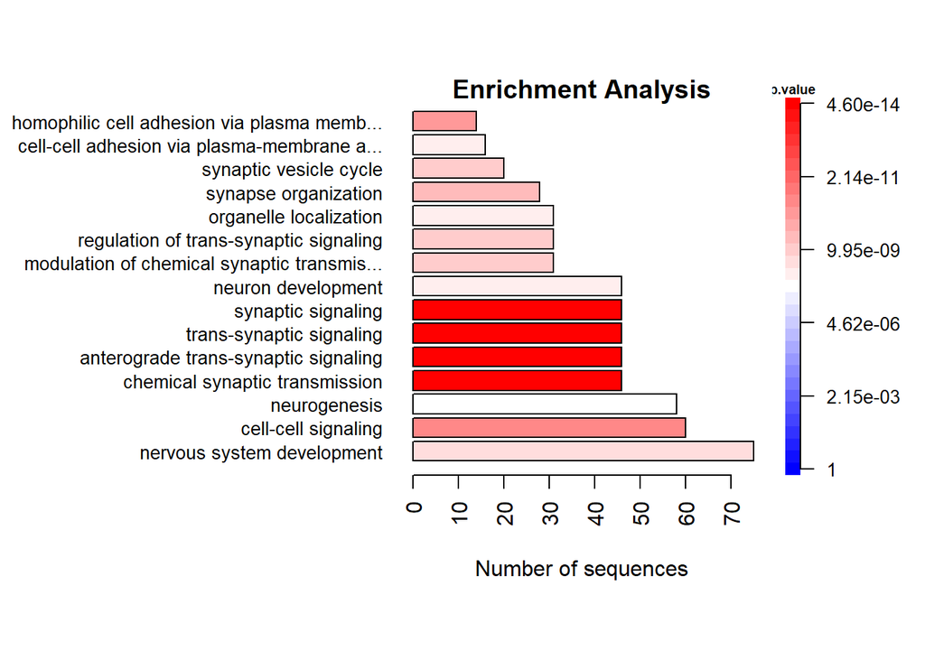

```r
# Plots
plotEnrich = function(allRes, title){
  # Plotting!
  layout(t(1:2), widths = c(8,1))
  par(mar=c(4, .5, .7, .7), oma = c(3, 15, 3, 4), las = 1)

  rbPal = colorRampPalette(c('red', 'white', 'blue'))
  pvalue = as.numeric(gsub("<", "", allRes$classicFisher))
  max_value = as.integer(max(-log(pvalue))) + 1
  pv_range = exp(-seq(max_value, 0, -1))
  allRes$Color = rbPal(max_value) [cut(pvalue, pv_range)]

  o = order(allRes$Significant, decreasing = T)
  barplot(allRes$Significant[o], names.arg = allRes$Term[o], las = 2, horiz = T, col = allRes$Color[o],
          xlab = "Number of sequences", main = title, cex.names = 0.85)

  image(0, seq(1, max_value), t(seq_along(seq(1, max_value))), col = rev(rbPal(max_value)), axes = F, ann = F)
  pv_label = exp(-seq(log(1), -log(min(pvalue)), l = 6))
  pv_label = formatC(pv_label, format = "e", digits = 2)
  axis(4, at = seq(1, max_value, length = 6), labels = c(1, pv_label[2:6]), cex.axis = 0.85)
  title("p.value", cex.main = 0.6)
}

plotEnrich(allRes = allRes, title = 'Enrichment Analysis')
```

Aquí podemos ver cómo los procesos biológicos más sobreexpresados serán los relacionados con la señal sináptica, la señalización trans-sináptica, la señalización anterógrada sináptica y la transmisión química sináptica, entre otros procesos también relacionados con la sinapsis y el procesamiento de transmisión de información. En definitiva, que tal y como se comenta en el paper asociado a estos datos, los genes DE en la región CA3 van a indicar que esta región va a mostrar mecanismos de remodelación sináptica, lo que puede servir como base para la codificación rápida de nueva información en la memoria a largo plazo.